# Revealing the Inequality (using incarceration data)

Risa Nabari

2022-11-19

## Abstract

This report uses the incarceration data set, and the key goal of this data set is to help understand the inequalities associated with people who have been incarcerated and who are in jail, specifically in the US society. We will be analyzing the number of jailed population of people with different colors as well as the growth of the U.S. prison population and state.

## Introduction

Understanding the inequalities associated with people who have been incarcerated and who are in jail, specifically in the US society is very crucial in order to eventually fight for human dignity, advocate for immigrants, invest in the communities, and to end mass incarceration. Mass incarceration robs people of dignity and tears at the fabric of communities. The biggest direct stakeholder includes those who are directly affected by this (mostly the people of color sent to jail and their family). The indirect stakeholders include the researchers, organizers, and the government (leader) who analyzes the data and to create evidence-based solutions that restore communities in order to end criminalization of people of color, immigrants, and people experiencing poverty. If we are able to analyze the data and draw important conclusions and if we are able to work out the solutions, we could create a new paradigm for public safety and racial justice. Thus in this report, we will be analyzing the number of jailed people with different colors, gender, as well as the growth of the U.S. prison population and state.

## Data Summary

In order to look at the inequalities associated with people who have been incarcerated and who are in jail, we will be looking at the jailed population by race and compare it with the population of each race to find the ratio. This will allow us to compare between each race and discuss if we are able to see a evidence of inequality. I have used the data from 2018 as having the most recent year would be the most relevant. The answers I will be answers is : What is the average value of the Asian American jailed population by the mean population of Asian American from age 15 to 64 ? What is the average value of the Black jailed population by the mean population of Black from age 15 to 64? What is the average value of the African American jailed population by the mean population of African American from age 15 to 64? What are the average value of the White jailed population by the mean population of White from age 15 to 64? What are the average value of the Latinx jailed population by the mean population of Latinx from age 15 to 64?

Here are the result:

#### **American Asian Pacific Islander : 5.1904298^{-4}**

#### **Black : 0.0090981**

#### **Latinx :0.008317**

#### **Native Americans : 0.005988**

#### **White : 0.002843**

*To get this result, I have selected the relevant columns, then found the mean jail population by filtering in year 2018. Then, found the ratio by dividing mean jail population of the certain race to the mean population from 15 to 64*

## Growth of the U.S. Prison Population

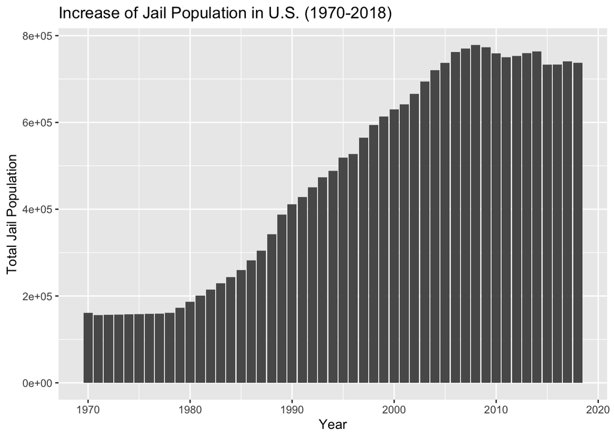

Figure 1: This graph shows the growth of U.S. prison population from 1970-2018

## Jail Population by States

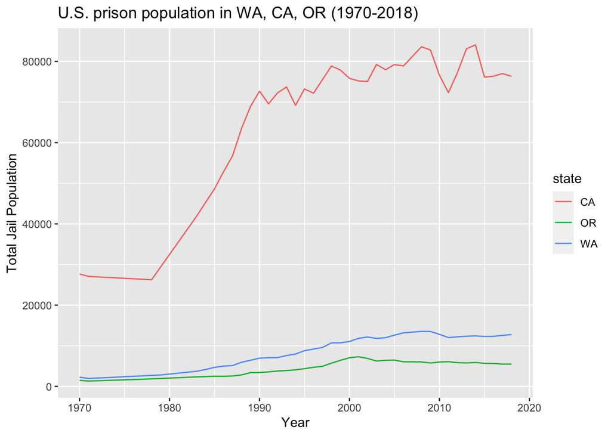

Figure 2: Growth of prison population in Washington, California, and Oregon over time (from 1970 to 2018).

**Summary**: In all three states, we can see that the prison population has increased over time. Oregon has the least number of prison population and has a slow steady slope. Washington also has a slow steady slope by slightly higher than the prison population of Oregon. On the other hand, California has a high jail population as seen in the graph. From 1970 to 1980, it was steady (although higher than the other two states) but from 1980 to 1990, it had a very steep slope which increased from around 28000 to 70000. Then, the numbers increased and decreased until 2020. But overall, the total jail population has increased. This could be because California is densely populated which can cause disparity between the community. I have chosen these states as I am currently living in Washington so I was curious on what the pattern was like. In addition, I wanted to compare the difference in the states located on the west coast to see if it would give a similar result.

## Variable Comparison

Here, we will be having a variable comparison that reveals potential patterns of inequality. In data summary, we have revealed the ratio of the mean jailed population to the whole population of different races. Now, is there a difference between women and men? Which gender may be potentially more vulnerable to getting incarcerated?

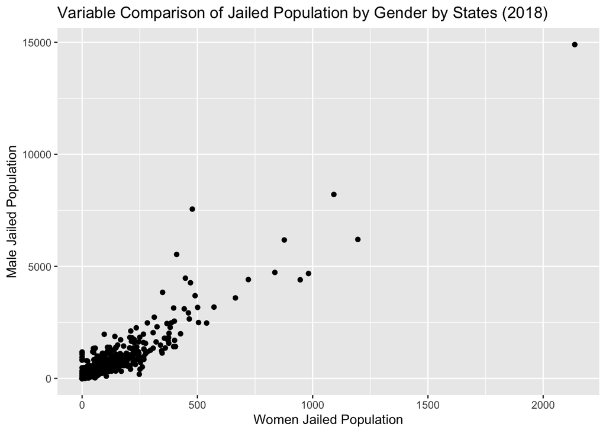

Figure 3: Variable comparison of jailed population by gender (men and women) in 2018 by states

**Summary**: Shown in the graph above, we can see that men has a higher number of jailed population compared to women. We can see this easily by the plots shown. For example, the value on the right corner has around 2200 jailed women and the mail population has around 15000, which is a big difference. This tells that overall, more men is in jail and this could potentially relate to inequality, where men are over 8 times more likely than women to be incarcerated in prison. Throughout this report, we have known that people with color and who are men has a higher population to be incarcerated in prison.

## Map Representing Potential Patterns of Inequality that Varies Geographically (in the U.S.)

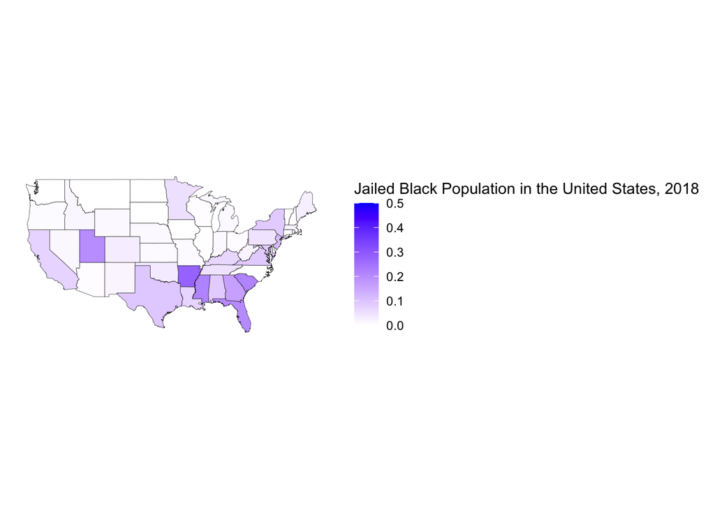

Figure 4: Presents the jailed black population in the United States (2018) by states which the more darker the color is, the more jailed black population in that state.